# Milestone 2

By Oliver Orejola

A link to this project can be found [here](https://oliverorejolacmps6790.github.io.).

## Project Plan

It is well know that correlation does not imply causation. However, it is less know (fist studied by Yule in 1926) that for large class of time-series distributions (specifically non-stationary ones), estimation of the correlation coefficient can often be non-sense. That is, with high-probability, the magnitude of the estimated correlation coeffieicnt of two independent non-stationary stochastic processes is close to 1. We say a processes is stationary (wide sense stationary) if it's variance does not change over time.

In light of this, Robert Engle and Clive Granger (1987) introduced the concept of cointegration. Loosely speaking, we say two non-stationary stochastic processes are cointegrated if there exists a linear combination of them which is stationary. Specifically, let $X(t)$ and $Y(t)$ be two non-stationary processes. We say $X(t)$ and $Y(t)$ are cointegrated if there exists constants $\alpha$ and $\beta$ such that the process

$$\alpha X(t) + \beta Y(t)$$

is stationary.

One can plot the price of stocks and visualy observe that they are non-stationary. In this project I plan to explore this relationship between different stocks. In particular, I will be studying conintegration among Apple (AAPL) stock and [15 major companies tied to the Apple supply chain](https://www.investopedia.com/articles/investing/090315/10-major-companies-tied-apple-supply-chain.asp#:~:text=One%20of%20the%20largest%20suppliers,popular%20products%2C%20including%20the%20iPhone.).

- Taiwan-Based
  - Foxconn (2354.TW) Taiwan Stock Exchange
  - Quanta Computers (2382.TW) Taiwan Stock Exchange
  - Taiwan Semiconductor Manufacturing Company (TSM) New York Stock Exchange
  - Wistron (3231.TW) Taiwan Stock Exchange
  - Pegatron (4938.TW) Taiwan Stock Exchange
- China-Based
  - GoerTek (002241.SZ) Shenzhen Stock Exchange
  - Luxshare (002475.SZ) Shenzhen Stock Exchange
- US-Based
  - 3M (MMM) New York Stock Exchange
  - Broadcom (AVGO) New York Stock Exchange
  - Qualcomm (QCOM) New York Stock Exchange
  - Intel (INTC) New York Stock Exchange
  - Jabil (JBL) New York Stock Exchange
  - On (ON) New York Stock Exchange
  - Micron (MU) New York Stock Exchange
  - Texas Instruments (TXN) New York Stock Exchange

## Project Data Set

For this project I will be loading in historical stock market data for each of the companies listed above. Our data consists of historical stock market data from 1/1/2018 to 10/1/2023. The data is taken using the [yahoo finanace api](https://pypi.org/project/yfinance/). For simplicity in our investigation of conintegraiton, we will only look at the value of the stock based on opening price for each day.

## Extract, Load, and Transform

### Extract

We first create a folder for us to store the data which we will save from the yahoo finance api. Then, we install the yfinance module.

```python
#! mkdir Data
# Install yahoo finance api
#! pip install yfinance
```

```python
# Import Relevant Libraries
import pandas as pd
from datetime import datetime as dt
import yfinance as yf
import matplotlib
import matplotlib.pyplot as plt
```

```python
# Create list of tuples including company tickers (reference id on stock exchange) and short hand name
tickers = ['AAPL', '2354.TW', '2382.TW', 'TSM', '3231.TW','4938.TW',
           '002241.SZ','002475.SZ',
           'MMM','AVGO','QCOM','INTC','JBL','ON','MU','TXN']
names = ['AAPL', 'Foxconn', 'Quanta', 'TSM', 'Wistron','Pegatron',
           'GoerTek','Luxshare',
           'MMM','AVGO','QCOM','INTC','JBL','ON','MU','TXN']

companies=dict(tuple(zip(names,tickers)))
```

```python
start_date = dt(2018, 1, 1)
end_date = dt(2023, 10, 1)

# Create folder to store Data
# ! mkdir Data
# Sort through list of of companies of interest
for comp in companies:

    name = comp
    ticker = companies[comp]

    #company_name = yf.Ticker(ticker).info['longName']
    company_name = name

    # Download data through yfinance api
    data = yf.download(ticker, start = start_date,end = end_date)
    data.reset_index(inplace=True)

    path = 'Data/'
    file_name = name+'.csv'

    # Save data as .csv
    data.to_csv(path+file_name, index=False)
    print(f'{company_name} ({ticker}) Historical Data Downloaded')
```

```
[*********************100%%**********************]  1 of 1 completed
AAPL (AAPL) Historical Data Downloaded
[*********************100%%**********************]  1 of 1 completed
Foxconn (2354.TW) Historical Data Downloaded
[*********************100%%**********************]  1 of 1 completed
Quanta (2382.TW) Historical Data Downloaded
[*********************100%%**********************]  1 of 1 completed
TSM (TSM) Historical Data Downloaded
[*********************100%%**********************]  1 of 1 completed
Wistron (3231.TW) Historical Data Downloaded
[*********************100%%**********************]  1 of 1 completed
Pegatron (4938.TW) Historical Data Downloaded
[*********************100%%**********************]  1 of 1 completed
GoerTek (002241.SZ) Historical Data Downloaded
[*********************100%%**********************]  1 of 1 completed
Luxshare (002475.SZ) Historical Data Downloaded
[*********************100%%**********************]  1 of 1 completed
MMM (MMM) Historical Data Downloaded
[*********************100%%**********************]  1 of 1 completed
AVGO (AVGO) Historical Data Downloaded
[*********************100%%**********************]  1 of 1 completed
QCOM (QCOM) Historical Data Downloaded
[*********************100%%**********************]  1 of 1 completed
INTC (INTC) Historical Data Downloaded
[*********************100%%**********************]  1 of 1 completed
JBL (JBL) Historical Data Downloaded
[*********************100%%**********************]  1 of 1 completed
ON (ON) Historical Data Downloaded
[*********************100%%**********************]  1 of 1 completed
MU (MU) Historical Data Downloaded
[*********************100%%**********************]  1 of 1 completed
TXN (TXN) Historical Data Downloaded
```

### Load & Transform

We now load in the historical data create a dictionary which stores the stock name as the key and the associated historical data as the value. In addition, we change the `Date` column to the appropriate `datetime` object for each dataframe.

```python
# Init blank dict
dict_of_tables = dict()

for comp in companies:
    name = comp
    ticker = companies[name]

    path = 'Data/'
    file_name = name+'.csv'
    data = pd.read_csv(path+file_name)

    # Convert column to datetime type
    data['Date'] = pd.to_datetime(data['Date'])
    dict_of_tables[name] = data
```

### Explore

We now plot the historical data for each stock.

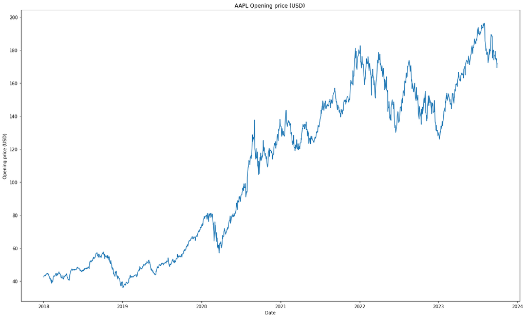

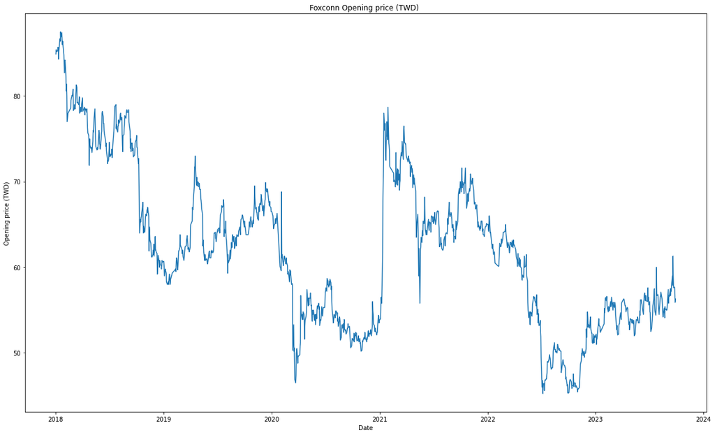

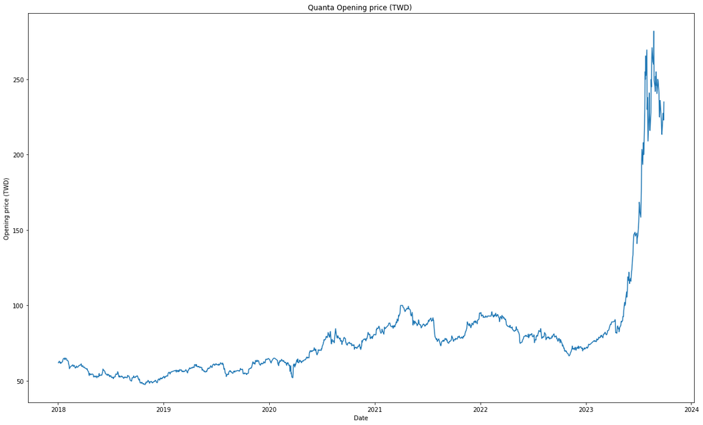

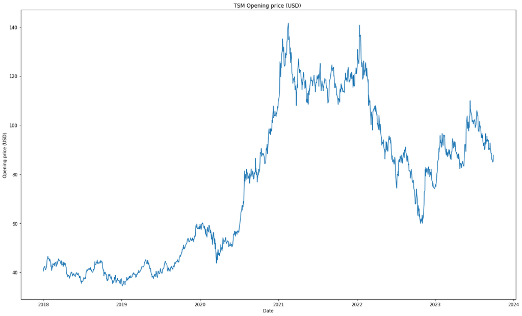

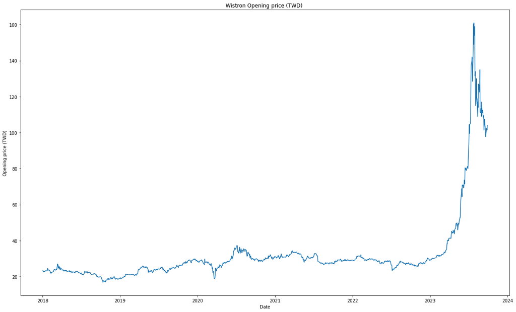

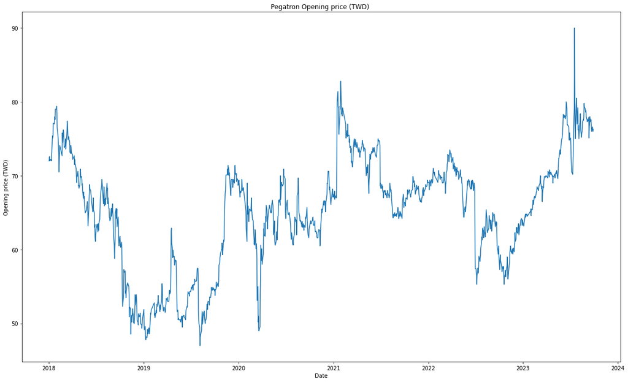

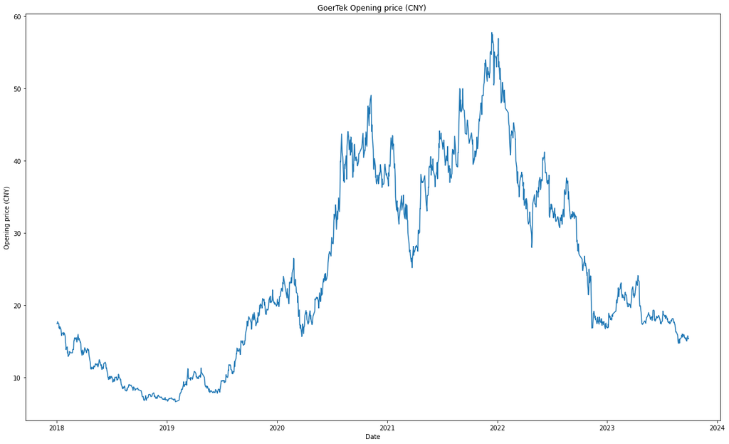

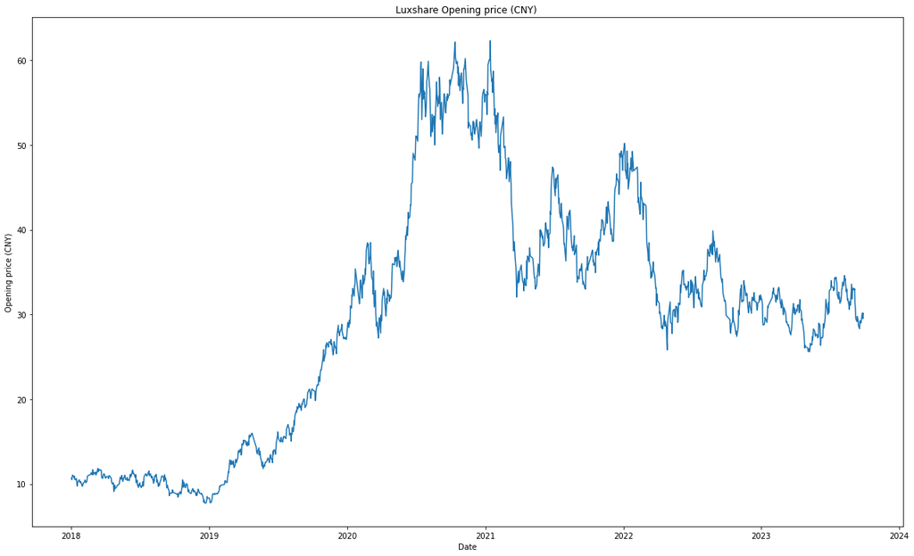

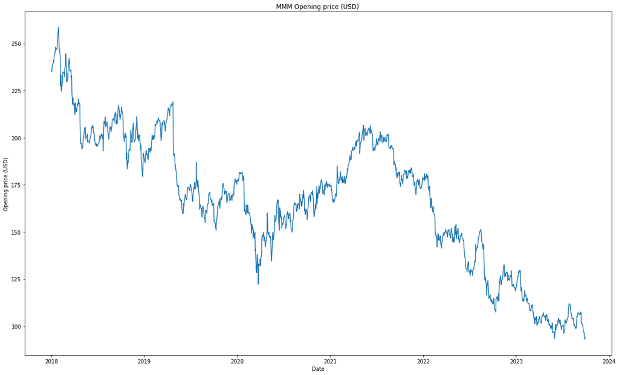

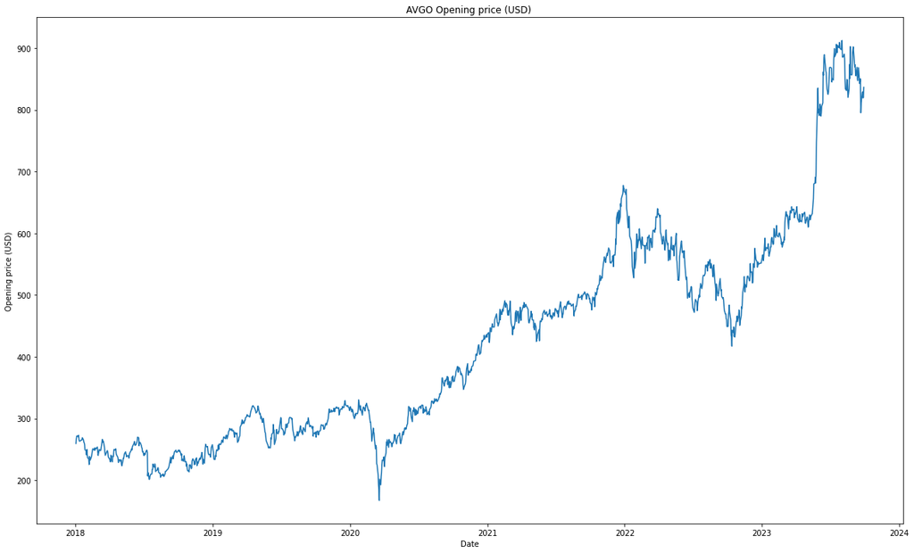

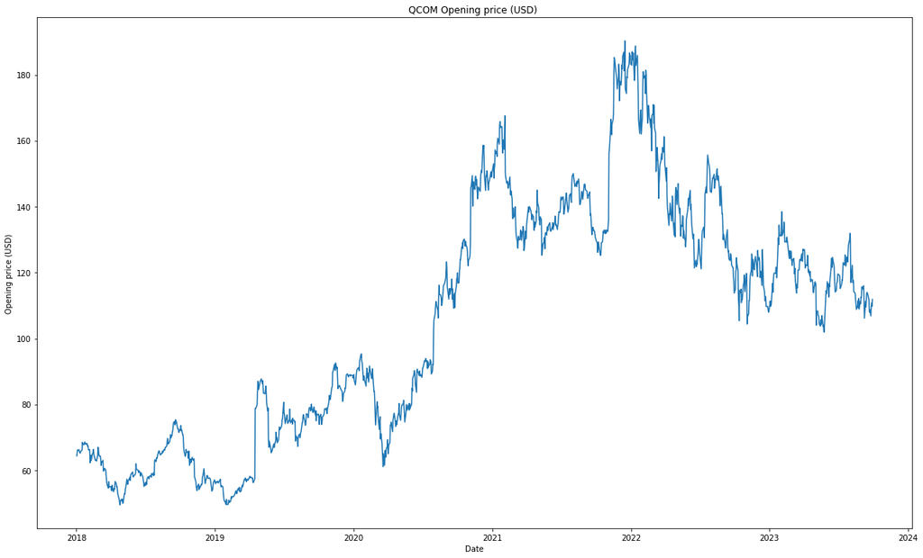

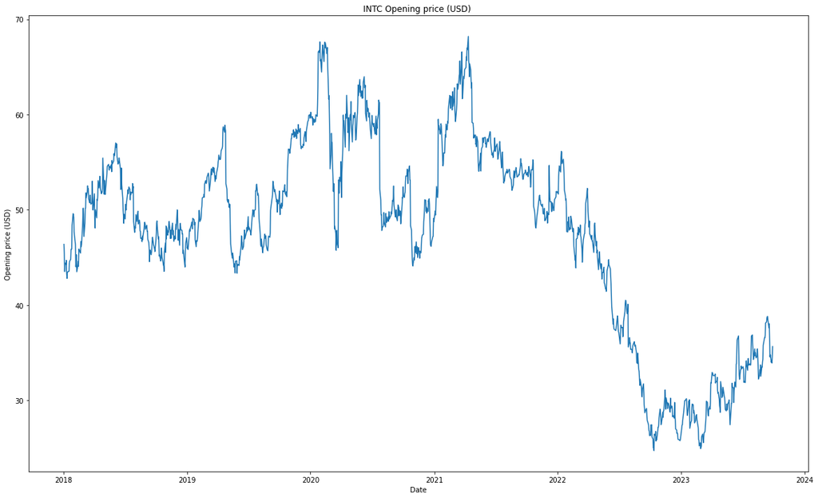

[4 more figures not shown]

```python
for comp in companies:
    name = comp
    ticker = companies[name]

    data =  dict_of_tables[name]

    # Get True Company name and native currency for which the stock is valued
    #company_name = yf.Ticker(ticker).info['longName']
    company_name = name
    currency = yf.Ticker(ticker).basic_info['currency']

    fig, ax = plt.subplots(figsize=(20, 12))

    # Add x-axis and y-axis
    ax.plot(data['Date'],data['Open'])

    # Set title and labels for axes
    ax.set(xlabel="Date",
       ylabel=f"Opening price ({currency})",
       title=f"{company_name} Opening price ({currency}) ")
    plt.show()
```

### Stationarity

Based on the plots above one expects the processes to be non-stationary. I.e. the plots look similar to brownian motion, or a random walk. We now verify that our processes are indeed non-stationary stochastic processes making use of hypothesis tests. We make use of two classic hypothesis tests for non-stationarity. We make use of the **augmented Dickey–Fuller test** and the **Kwiatkowski–Phillips–Schmidt–Shin** (**KPSS**).

The **augmented Dickey–Fuller test** (**ADF**) tests the following hypothesis:

$H_0:$ The Stochastic Process is Non-Stationary vs $H_a:$ The Stochastic Process is Stationary.

We use the ADF test in combination with the KPSS test. Where the **Kwiatkowski–Phillips–Schmidt–Shin** (**KPSS**) tests the following hypothesis:

$H_0:$ The Stochastic Process is Stationary vs $H_a:$ The Stochastic Process is Non-Stationary.

To compute these tests we use the module [`statsmodels`](https://www.statsmodels.org/stable/index.html). In particular, we make use of [`statsmodels.tsa`](https://www.statsmodels.org/stable/tsa.html) which proves usefull for time-series analysis.

```python
from statsmodels.tsa.stattools import adfuller , kpss

import warnings

df_test_statistics = pd.DataFrame(columns=['Name','Company Name','Ticker','Currency','ADF Test Statistic','ADF p-value','KPSS Test Statistic','KPSS p-value'])

for comp in companies:
    name = comp
    ticker = companies[name]
    #company_name = yf.Ticker(ticker).info['longName']
    company_name = name
    currency = yf.Ticker(ticker).basic_info['currency']

    data =  dict_of_tables[name]
    adf = adfuller(data['Open'],regression='ctt')
    adf_test_stat = adf[0]
    adf_pvalue = adf[1]

    # We ignore warnings here as we encounter a minor warning when computing the kpss test statistic.
    # The p-values are returned are larger than the actual p-values
    with warnings.catch_warnings():
        warnings.simplefilter('ignore')
        kp=kpss(data['Open'], regression='ct', nlags='auto', store=False)

    kpss_test_stat= kp[0]
    kpss_pvalue= kp[1]
    row = [name,company_name,ticker,currency,adf_test_stat,adf_pvalue,kpss_test_stat,kpss_pvalue]
    df_test_statistics.loc[len(df_test_statistics.index)] = row
```

```python
display(df_test_statistics)
```

|  | Name | Company Name | Ticker | Currency | ADF Test Statistic | ADF p-value | KPSS Test Statistic | KPSS p-value |
| --- | --- | --- | --- | --- | --- | --- | --- | --- |
| 0 | AAPL | AAPL | AAPL | USD | -2.480111 | 0.580714 | 0.477148 | 0.01 |
| 1 | Foxconn | Foxconn | 2354.TW | TWD | -3.205026 | 0.207262 | 0.371421 | 0.01 |
| 2 | Quanta | Quanta | 2382.TW | TWD | -1.410760 | 0.957305 | 0.297643 | 0.01 |
| 3 | TSM | TSM | TSM | USD | -2.090215 | 0.780086 | 0.779867 | 0.01 |
| 4 | Wistron | Wistron | 3231.TW | TWD | -1.664145 | 0.915972 | 0.444606 | 0.01 |
| 5 | Pegatron | Pegatron | 4938.TW | TWD | -3.197411 | 0.210161 | 0.322638 | 0.01 |
| 6 | GoerTek | GoerTek | 002241.SZ | CNY | -2.821889 | 0.386351 | 1.107536 | 0.01 |
| 7 | Luxshare | Luxshare | 002475.SZ | CNY | -2.754282 | 0.423642 | 1.218327 | 0.01 |
| 8 | MMM | MMM | MMM | USD | -2.645412 | 0.485573 | 0.553218 | 0.01 |
| 9 | AVGO | AVGO | AVGO | USD | -3.049666 | 0.272056 | 0.408435 | 0.01 |
| 10 | QCOM | QCOM | QCOM | USD | -2.831111 | 0.381359 | 0.788662 | 0.01 |
| 11 | INTC | INTC | INTC | USD | -3.165116 | 0.222778 | 0.990353 | 0.01 |
| 12 | JBL | JBL | JBL | USD | -1.911712 | 0.848455 | 0.676233 | 0.01 |
| 13 | ON | ON | ON | USD | -5.039596 | 0.000877 | 1.111241 | 0.01 |
| 14 | MU | MU | MU | USD | -2.565669 | 0.531591 | 0.536230 | 0.01 |
| 15 | TXN | TXN | TXN | USD | -2.193035 | 0.733320 | 0.638727 | 0.01 |

We note that the suppressed warning returned by the KPSS test reads. `InterpolationWarning: The test statistic is outside of the range of p-values available in the look-up table. The actual p-value is smaller than the p-value returned.` Namely, for almost any reasonable siginificance level we should reject the hypothesis that these processes are stationary.

## Correlation

We now entertain the idea of correllation between these stockmarket data. For simplicity we only consider the covariance between stocks traded in USD. Todo so, we create a dataframe whose columns consist of the stock ticker, and the rows correspond to opening price for a particular date.

```python
us_names = ['AAPL', 'MMM','AVGO','QCOM','INTC','JBL','ON','MU','TXN']

frames = [dict_of_tables[name].Open for name in us_names]
df_us_open = pd.concat(frames,axis = 1, keys = us_names)
df_us_open=df_us_open.merge(dict_of_tables[name].Date, left_index=True, right_index=True)


# Reorder columns
df_us_open = df_us_open[['Date']+us_names]
display(df_us_open.head(20))
```

|  | Date | AAPL | MMM | AVGO | QCOM | INTC | JBL | ON | MU | TXN |
| --- | --- | --- | --- | --- | --- | --- | --- | --- | --- | --- |
| 0 | 2018-01-02 | 42.540001 | 235.779999 | 259.769989 | 64.379997 | 46.380001 | 26.500000 | 21.030001 | 41.540001 | 105.110001 |
| 1 | 2018-01-03 | 43.132500 | 235.070007 | 267.290009 | 65.220001 | 45.470001 | 26.799999 | 22.000000 | 44.500000 | 105.879997 |
| 2 | 2018-01-04 | 43.134998 | 237.000000 | 271.589996 | 66.180000 | 43.520000 | 27.219999 | 23.170000 | 45.990002 | 108.480003 |
| 3 | 2018-01-05 | 43.360001 | 238.649994 | 271.970001 | 66.040001 | 44.430000 | 27.490000 | 22.850000 | 46.130001 | 108.699997 |
| 4 | 2018-01-08 | 43.587502 | 239.380005 | 270.920013 | 66.250000 | 44.270000 | 27.180000 | 22.850000 | 45.310001 | 108.550003 |
| 5 | 2018-01-09 | 43.637501 | 239.600006 | 273.059998 | 65.639999 | 44.700001 | 27.129999 | 22.879999 | 45.270000 | 109.620003 |
| 6 | 2018-01-10 | 43.290001 | 241.000000 | 265.980011 | 65.480003 | 43.330002 | 26.799999 | 22.639999 | 41.950001 | 109.849998 |
| 7 | 2018-01-11 | 43.647499 | 240.740005 | 263.570007 | 65.199997 | 42.799999 | 27.000000 | 22.799999 | 43.520000 | 110.050003 |
| 8 | 2018-01-12 | 44.044998 | 243.070007 | 263.390015 | 65.610001 | 43.450001 | 27.400000 | 23.129999 | 42.820000 | 110.739998 |
| 9 | 2018-01-16 | 44.474998 | 245.300003 | 265.179993 | 66.230003 | 43.549999 | 27.870001 | 23.820000 | 43.139999 | 113.550003 |
| 10 | 2018-01-17 | 44.037498 | 246.850006 | 265.480011 | 68.519997 | 43.549999 | 27.730000 | 23.620001 | 43.209999 | 113.949997 |
| 11 | 2018-01-18 | 44.842499 | 248.130005 | 265.459991 | 67.750000 | 44.400002 | 28.200001 | 24.059999 | 44.209999 | 119.000000 |
| 12 | 2018-01-19 | 44.652500 | 246.630005 | 269.149994 | 68.040001 | 44.619999 | 28.260000 | 24.920000 | 43.950001 | 117.010002 |
| 13 | 2018-01-22 | 44.325001 | 247.130005 | 265.649994 | 67.809998 | 44.799999 | 26.830000 | 25.170000 | 42.470001 | 117.919998 |
| 14 | 2018-01-23 | 44.325001 | 246.910004 | 261.739990 | 68.599998 | 45.810001 | 26.660000 | 25.500000 | 43.250000 | 120.019997 |
| 15 | 2018-01-24 | 44.312500 | 247.990005 | 260.970001 | 68.199997 | 45.900002 | 27.209999 | 24.660000 | 43.759998 | 111.139999 |
| 16 | 2018-01-25 | 43.627499 | 250.000000 | 257.739990 | 68.139999 | 45.880001 | 27.030001 | 24.910000 | 44.230000 | 110.860001 |
| 17 | 2018-01-26 | 43.000000 | 253.429993 | 249.419998 | 67.940002 | 48.380001 | 26.219999 | 24.410000 | 43.220001 | 110.930000 |
| 18 | 2018-01-29 | 42.540001 | 258.510010 | 248.279999 | 68.160004 | 49.599998 | 26.350000 | 25.010000 | 43.250000 | 112.470001 |
| 19 | 2018-01-30 | 41.382500 | 255.600006 | 241.250000 | 67.430000 | 49.480000 | 25.540001 | 25.080000 | 41.990002 | 111.199997 |

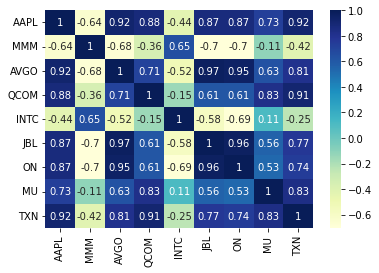

```python
import seaborn as sns
sns.heatmap(df_us_open.corr(),cmap="YlGnBu", annot=True)
plt.show()
```

### Cointegration

We now aim to check for cointegration between Apple and other stocks traded in USD. Here we use the dataframe which was used to compute correlation. In particular, we would like to estimate $\alpha$ and $\beta$ and $\gamma$ such that $\alpha X(t) + \beta Y(t) + \gamma $ is stationary. To do so, we follow the Engle-Granger Two Step Method.

1. Estimate $\alpha/\beta$ and $\gamma/\beta$ by means of ordinary least squares. In particular we regress $X(t)$ on $Y(t)$ such that we obtain estimates

$$\hat{Y}(t) = \alpha/\beta X(t) + \gamma/\beta$$

1. Use the Augmented Dicky-Fuller test to check for stationarity of the residuals given by

$$Y(t) - \hat{Y}(t) = Y(t) - (\alpha/\beta X(t) + \gamma/\beta) $$

```python
us_names.remove('AAPL') # Remove apple from list of us companies
```

```python
from scipy import stats

# Create Blank Dataframe To store Cointegration data
df_us_conintegration = pd.DataFrame(columns=['Company Name',
                                             'Ticker',
                                             'Slope',
                                             'Intercept',
                                             'ADF Test Statistic',
                                             'ADF p-value'])

for name in us_names:
    ticker = companies[name]

    #company_name = yf.Ticker(ticker).info['longName']
    company_name = name

    # Fit OLS
    slope, intercept, r_value, p_value, std_err = stats.linregress(df_us_open[name],df_us_open['AAPL'])
    spread = -df_us_open['AAPL'] + slope*df_us_open[name]+intercept

    # Perform ADF test on Spread
    adf = adfuller(spread, regression='ctt')
    adf_test_stat = adf[0]
    adf_pvalue = adf[1]

    row = [company_name,ticker,slope,intercept,adf_test_stat,adf_pvalue]
    df_us_conintegration.loc[len(df_us_conintegration.index)] = row
```

```python
display(df_us_conintegration)
```

|  | Company Name | Ticker | Slope | Intercept | ADF Test Statistic | ADF p-value |
| --- | --- | --- | --- | --- | --- | --- |
| 0 | MMM | MMM | -0.888739 | 255.157958 | -2.366122 | 0.644345 |
| 1 | AVGO | AVGO | 0.265330 | -4.879864 | -2.427173 | 0.610619 |
| 2 | QCOM | QCOM | 1.200542 | -20.052594 | -4.014205 | 0.030249 |
| 3 | INTC | INTC | -2.134599 | 208.664442 | -2.884895 | 0.352778 |
| 4 | JBL | JBL | 1.926983 | 14.037878 | -1.433853 | 0.954474 |
| 5 | ON | ON | 1.790497 | 34.516817 | -3.473362 | 0.119802 |
| 6 | MU | MU | 2.326150 | -28.989116 | -3.270147 | 0.182675 |
| 7 | TXN | TXN | 1.401857 | -97.423891 | -3.255647 | 0.187877 |

### Cointegration over intervals

```python
t=50 # Set length of time interval
n=len(df_us_open)

df_us_conintegration_window = pd.DataFrame(columns=['Company Name',
                                                    'Ticker',
                                                    'Slope',
                                                    'Intercept',
                                                    'ADF Test Statistic',
                                                    'ADF p-value',
                                                    'Date Initial',
                                                    'Date Final'])

for i in range(int(n/t)+1):
    m = i*t
    M = min(t*(i+1),n-1)
    date_time_min = df_us_open.iloc[m]['Date']
    date_time_max = df_us_open.iloc[M]['Date']
    date_min = str(date_time_min.year) + '-' +str(date_time_min.month) +'-' +str(date_time_min.day)
    date_max = str(date_time_max.year) + '-' +str(date_time_max.month) +'-' +str(date_time_max.day)

    date_interval = date_min + ' to ' + date_max


    for name in us_names:
        ticker = companies[name]

        #company_name = yf.Ticker(ticker).info['longName']
        company_name = name
        slope, intercept, r_value, p_value, std_err = stats.linregress(df_us_open.iloc[m:M][name],df_us_open.iloc[m:M]['AAPL'])
        spread = -df_us_open['AAPL'] + slope*df_us_open[name]+intercept

        adf = adfuller(spread,regression = 'ct',autolag= 'BIC')
        adf_test_stat = adf[0]
        adf_pvalue = adf[1]


        row = [company_name,ticker,slope,intercept,adf_test_stat,adf_pvalue, date_time_min,date_time_max ]
        df_us_conintegration_window.loc[len(df_us_conintegration_window.index)] = row
    print(f"Cointegration Computation Completed for {date_interval}")
```

```
Cointegration Computation Completed for 2018-1-2 to 2018-3-15
Cointegration Computation Completed for 2018-3-15 to 2018-5-25
Cointegration Computation Completed for 2018-5-25 to 2018-8-7
Cointegration Computation Completed for 2018-8-7 to 2018-10-17
Cointegration Computation Completed for 2018-10-17 to 2018-12-31
Cointegration Computation Completed for 2018-12-31 to 2019-3-14
Cointegration Computation Completed for 2019-3-14 to 2019-5-24
Cointegration Computation Completed for 2019-5-24 to 2019-8-6
Cointegration Computation Completed for 2019-8-6 to 2019-10-16
Cointegration Computation Completed for 2019-10-16 to 2019-12-27
Cointegration Computation Completed for 2019-12-27 to 2020-3-11
Cointegration Computation Completed for 2020-3-11 to 2020-5-21
Cointegration Computation Completed for 2020-5-21 to 2020-8-3
Cointegration Computation Completed for 2020-8-3 to 2020-10-13
Cointegration Computation Completed for 2020-10-13 to 2020-12-23
Cointegration Computation Completed for 2020-12-23 to 2021-3-9
Cointegration Computation Completed for 2021-3-9 to 2021-5-19
Cointegration Computation Completed for 2021-5-19 to 2021-7-30
Cointegration Computation Completed for 2021-7-30 to 2021-10-11
Cointegration Computation Completed for 2021-10-11 to 2021-12-21
Cointegration Computation Completed for 2021-12-21 to 2022-3-4
Cointegration Computation Completed for 2022-3-4 to 2022-5-16
Cointegration Computation Completed for 2022-5-16 to 2022-7-28
Cointegration Computation Completed for 2022-7-28 to 2022-10-7
Cointegration Computation Completed for 2022-10-7 to 2022-12-19
Cointegration Computation Completed for 2022-12-19 to 2023-3-3
Cointegration Computation Completed for 2023-3-3 to 2023-5-15
Cointegration Computation Completed for 2023-5-15 to 2023-7-27
Cointegration Computation Completed for 2023-7-27 to 2023-9-29
```

Check for presence of statistically significant stationary within the spread using a generous significance level of 0.1.

```python
cointegration = df_us_conintegration_window.loc[ df_us_conintegration_window['ADF p-value'] < 0.1].copy()
display(df_us_conintegration_window)
```

|  | Company Name | Ticker | Slope | Intercept | ADF Test Statistic | ADF p-value | Date Initial | Date Final |
| --- | --- | --- | --- | --- | --- | --- | --- | --- |
| 0 | MMM | MMM | 0.073996 | 25.314086 | -2.803108 | 0.195805 | 2018-01-02 | 2018-03-15 |
| 1 | AVGO | AVGO | 0.104293 | 16.635221 | -2.022065 | 0.589364 | 2018-01-02 | 2018-03-15 |
| 2 | QCOM | QCOM | 0.005587 | 42.679317 | -2.698491 | 0.236710 | 2018-01-02 | 2018-03-15 |
| 3 | INTC | INTC | 0.234968 | 32.074073 | -2.726424 | 0.225276 | 2018-01-02 | 2018-03-15 |
| 4 | JBL | JBL | 1.536750 | 2.020769 | 0.139700 | 0.995402 | 2018-01-02 | 2018-03-15 |
| ... | ... | ... | ... | ... | ... | ... | ... | ... |
| 227 | INTC | INTC | 0.474937 | 164.107940 | -2.762822 | 0.210934 | 2023-07-27 | 2023-09-29 |
| 228 | JBL | JBL | 1.084612 | 63.684640 | -0.685165 | 0.974105 | 2023-07-27 | 2023-09-29 |
| 229 | ON | ON | 1.177711 | 66.640454 | -1.563037 | 0.806572 | 2023-07-27 | 2023-09-29 |
| 230 | MU | MU | 1.097594 | 106.122936 | -3.728852 | 0.020526 | 2023-07-27 | 2023-09-29 |
| 231 | TXN | TXN | 1.226587 | -24.332147 | -3.161311 | 0.092390 | 2023-07-27 | 2023-09-29 |

232 rows × 8 columns

We see that there are multiple intervals where cointegration is statistically significant. Interestingly they are mostly Qualcom (QCOM), Texas Instruments(TXN), 3M (MMM), Micro Technologies INC (MU). Below we plot them to get a visual sense of their relationship.

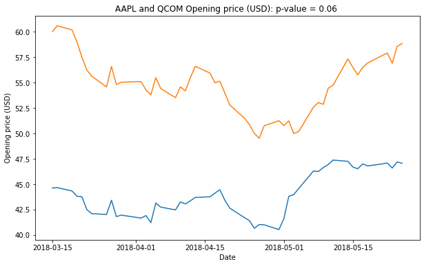

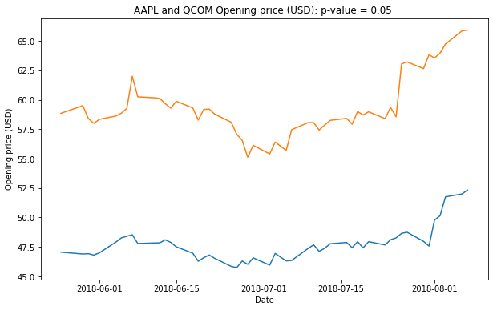

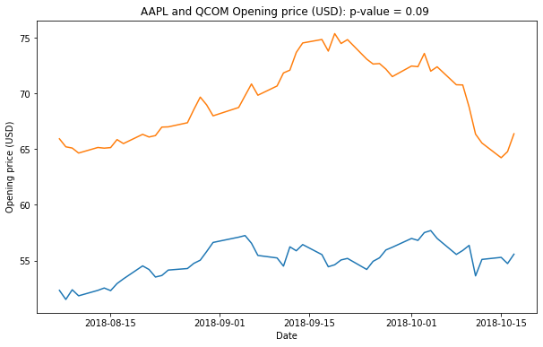

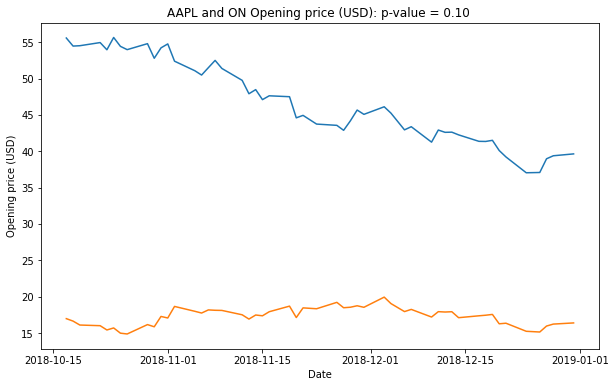

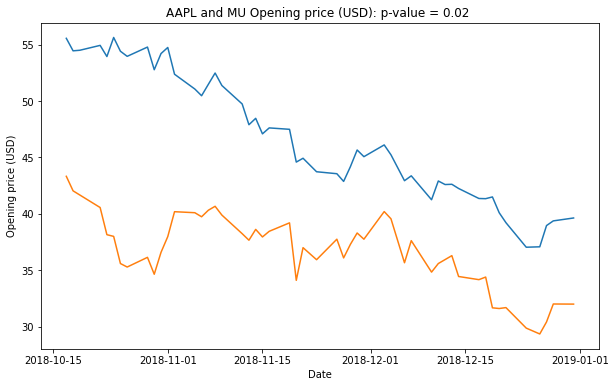

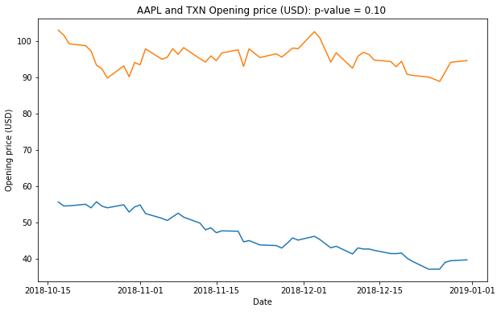

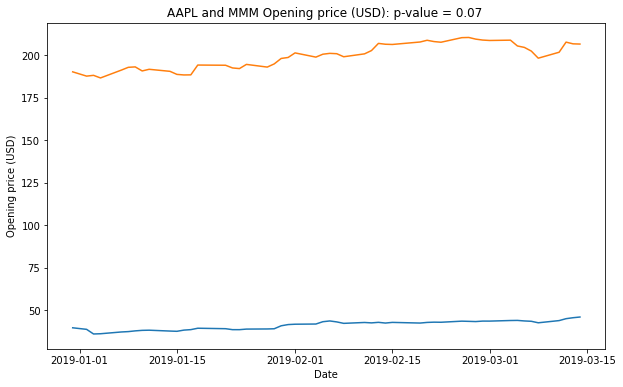

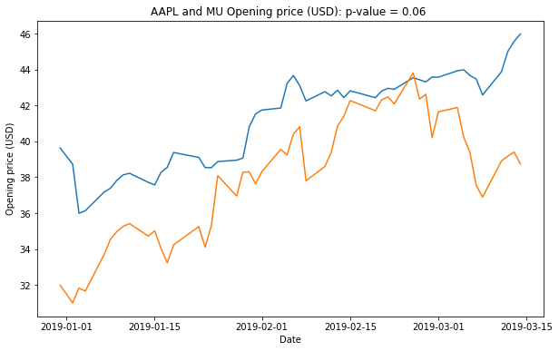

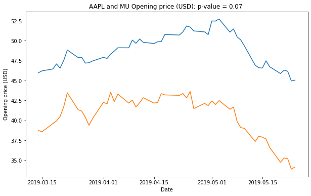

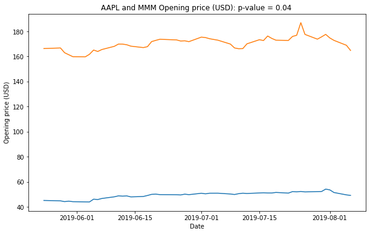

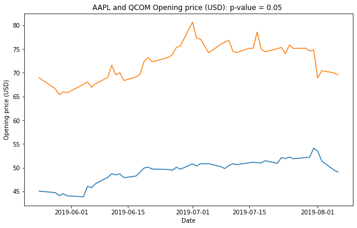

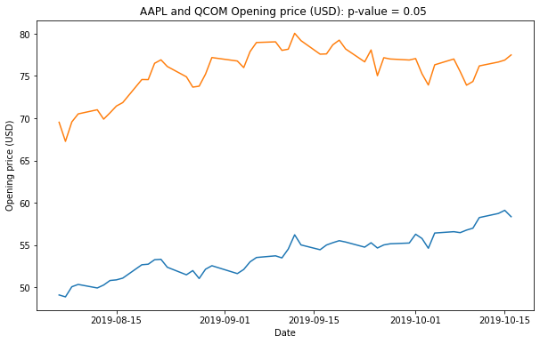

[44 more figures not shown]

```python
for i in range(len(cointegration)):
    row = cointegration.iloc[i]
    company_name = row['Company Name']
    date_init = row['Date Initial']
    date_final = row['Date Final']
    p_value = row['ADF p-value']


    data_AAPL = df_us_open[['AAPL','Date']].loc[(df_us_open['Date']>=date_init) & (df_us_open['Date']<=date_final) ]
    data_company = df_us_open[[company_name,'Date']].loc[(df_us_open['Date']>=date_init) & (df_us_open['Date']<=date_final) ]

    fig, ax = plt.subplots(figsize=(10, 6))

    # Add x-axis and y-axis
    ax.plot(data_AAPL['Date'],data_AAPL['AAPL'])
    ax.plot(data_company['Date'],data_company[company_name])
    # Set title and labels for axes
    ax.set(xlabel="Date",
       ylabel=f"Opening price ({currency})",
       title=f"AAPL and {company_name} Opening price ({currency}): p-value = {p_value:0.2f} ")
    plt.show()
```

## Models

In the previous section we have demonstrated that the stock market data is indeed non-stationary. We propose two models in an attempt to predict apple stock using the other stocks which appear in Apple's supply chain. In partciular we make use of one modern and one classical model. For the classical model, we aim to fit an Multivariate Generalized AutoRegressive Conditional Heteroskedasticity (MGARCH) model. This is appropriate for non-stationary distributions. For our modern model, we plan to Long Short Term Memory (LSTM) neural network.